# monique_bucknor_final

## Department of Mathematics College of Arts and Sciences, Howard University MATH 014 - Introduction to Data Science Final Project

### Student Name: Monique Bucknor Due date: 04-29-2025 Student ID: @03133387

**Link to Dataset**: [Diabetes Prediction Data Set](https://www.kaggle.com/datasets/marshalpatel3558/diabetes-prediction-dataset)  
This project explores biometric, lifestyle, and hereditary factors influencing diabetes using a predictive health dataset is generated by code provided by Perplexity AI for practice. The dataset contains biometric, lifestyle, and hereditary information for a diverse group of individuals.

Key variables include *age, gender, body mass index (BMI), fasting blood glucose levels, hemoglobin A1c (HbA1c) percentages, waist circumference,* and several lifestyle factors such as *smoking status, alcohol consumption level, and physical activity levels.* The dataset also includes whether individuals have a family history of diabetes, offering valuable insight into hereditary risk factors.

Through data cleaning, visualization, and basic statistical analysis, it makes it possible to identify the patterns that could help in understanding the most significant factors to diabetes development.

```python
import numpy as np
import pandas as pd
import matplotlib.pyplot as plt
import seaborn as sns
import plotly.express as px
import plotly.graph_objects as go
import os
```

### DATA UNDERSTANDING AND CLEANING

**Objective: Understand the dataset and clean it for analysis**

#### Understand the dataset by examining

```python
# Import dataset, redefining what counts as NA values
df = pd.read_csv("C:/Users/pfmij/In_Class_Assignments/Monique_Bucknor_Proj2FinalProj/Monique_Bucknor_Final_Proj/diabetes_dataset.csv", keep_default_na=False, na_values=[])
df_read = df.copy()
```

```python
# Print first 5 rows of dataset
df_read.head()
```

|  | Unnamed: 0 | Age | Sex | Ethnicity | BMI | Waist_Circumference | Fasting_Blood_Glucose | HbA1c | Blood_Pressure_Systolic | Blood_Pressure_Diastolic | ... | Cholesterol_HDL | Cholesterol_LDL | GGT | Serum_Urate | Physical_Activity_Level | Dietary_Intake_Calories | Alcohol_Consumption | Smoking_Status | Family_History_of_Diabetes | Previous_Gestational_Diabetes |
| --- | --- | --- | --- | --- | --- | --- | --- | --- | --- | --- | --- | --- | --- | --- | --- | --- | --- | --- | --- | --- | --- |
| 0 | 0 | 58 | Female | White | 35.8 | 83.4 | 123.9 | 10.9 | 152 | 114 | ... | 50.2 | 99.2 | 37.5 | 7.2 | Moderate | 1538 | Moderate | Never | 0 | 1 |
| 1 | 1 | 48 | Male | Asian | 24.1 | 71.4 | 183.7 | 12.8 | 103 | 91 | ... | 62.0 | 146.4 | 88.5 | 6.1 | Moderate | 2653 | Moderate | Current | 0 | 1 |
| 2 | 2 | 34 | Female | Black | 25.0 | 113.8 | 142.0 | 14.5 | 179 | 104 | ... | 32.1 | 164.1 | 56.2 | 6.9 | Low | 1684 | Heavy | Former | 1 | 0 |
| 3 | 3 | 62 | Male | Asian | 32.7 | 100.4 | 167.4 | 8.8 | 176 | 118 | ... | 41.1 | 84.0 | 34.4 | 5.4 | Low | 3796 | Moderate | Never | 1 | 0 |
| 4 | 4 | 27 | Female | Asian | 33.5 | 110.8 | 146.4 | 7.1 | 122 | 97 | ... | 53.9 | 92.8 | 81.9 | 7.4 | Moderate | 3161 | Heavy | Current | 0 | 0 |

5 rows × 21 columns

```python
# Check and Print Datatypes
df_read.dtypes
```

```
Unnamed: 0                         int64
Age                                int64
Sex                               object
Ethnicity                         object
BMI                              float64
Waist_Circumference              float64
Fasting_Blood_Glucose            float64
HbA1c                            float64
Blood_Pressure_Systolic            int64
Blood_Pressure_Diastolic           int64
Cholesterol_Total                float64
Cholesterol_HDL                  float64
Cholesterol_LDL                  float64
GGT                              float64
Serum_Urate                      float64
Physical_Activity_Level           object
Dietary_Intake_Calories            int64
Alcohol_Consumption               object
Smoking_Status                    object
Family_History_of_Diabetes         int64
Previous_Gestational_Diabetes      int64
dtype: object
```

```python
df_read.info()
```

```
<class 'pandas.core.frame.DataFrame'>
RangeIndex: 10000 entries, 0 to 9999
Data columns (total 21 columns):
 #   Column                         Non-Null Count  Dtype
---  ------                         --------------  -----
 0   Unnamed: 0                     10000 non-null  int64
 1   Age                            10000 non-null  int64
 2   Sex                            10000 non-null  object
 3   Ethnicity                      10000 non-null  object
 4   BMI                            10000 non-null  float64
 5   Waist_Circumference            10000 non-null  float64
 6   Fasting_Blood_Glucose          10000 non-null  float64
 7   HbA1c                          10000 non-null  float64
 8   Blood_Pressure_Systolic        10000 non-null  int64
 9   Blood_Pressure_Diastolic       10000 non-null  int64
 10  Cholesterol_Total              10000 non-null  float64
 11  Cholesterol_HDL                10000 non-null  float64
 12  Cholesterol_LDL                10000 non-null  float64
 13  GGT                            10000 non-null  float64
 14  Serum_Urate                    10000 non-null  float64
 15  Physical_Activity_Level        10000 non-null  object
 16  Dietary_Intake_Calories        10000 non-null  int64
 17  Alcohol_Consumption            10000 non-null  object
 18  Smoking_Status                 10000 non-null  object
 19  Family_History_of_Diabetes     10000 non-null  int64
 20  Previous_Gestational_Diabetes  10000 non-null  int64
dtypes: float64(9), int64(7), object(5)
memory usage: 1.6+ MB
```

```python
print(df_read['Age'], df_read['Sex'], df_read['BMI'])
```

```
0       58
1       48
2       34
3       62
4       27
        ..
9995    45
9996    41
9997    50
9998    62
9999    29
Name: Age, Length: 10000, dtype: int64 0       Female
1         Male
2       Female
3         Male
```

[output cut: 19 more lines]

```python
# Checking for null values
print(df_read.isnull().sum())
```

```
Unnamed: 0                       0
Age                              0
Sex                              0
Ethnicity                        0
BMI                              0
Waist_Circumference              0
Fasting_Blood_Glucose            0
HbA1c                            0
Blood_Pressure_Systolic          0
Blood_Pressure_Diastolic         0
Cholesterol_Total                0
Cholesterol_HDL                  0
Cholesterol_LDL                  0
GGT                              0
Serum_Urate                      0
Physical_Activity_Level          0
Dietary_Intake_Calories          0
Alcohol_Consumption              0
Smoking_Status                   0
Family_History_of_Diabetes       0
Previous_Gestational_Diabetes    0
dtype: int64
```

#### Cleaning Requirements

During the cleaning process, **3320** null values were found within the Alcohol Consumption category, however when reviewing the csv file itself, there were no null values. In fact, in checking the rows using ***("null_rows = df_read[df_read['Alcohol_Consumption'].isnull()] print(null_rows.index.tolist())")**, it stated that non-null value rows, rows that said "None" were null.  
In an effort to retain the existing values, in importing that dataset, I redefined the pandas automatic Null Value check to only* check for blank cells.

```python
# Convert appropriate columns (e.g., "Sex", "Smoking_Status") to categorical types.

# Checking data types for easy reference
df_read.dtypes

# Converting Family History of Diabetes to boolean
df_read['Family_History_of_Diabetes']  = df_read['Family_History_of_Diabetes'].astype(bool)

# Converting Previous Gestational Diabetes to boolean
df_read['Previous_Gestational_Diabetes'] = df_read['Previous_Gestational_Diabetes'].astype(bool)

# Print Results
print(df_read['Family_History_of_Diabetes'], df_read['Previous_Gestational_Diabetes'])
```

```
0       False
1       False
2        True
3        True
4       False
        ...
9995     True
9996     True
9997     True
9998     True
9999     True
Name: Family_History_of_Diabetes, Length: 10000, dtype: bool 0        True
1        True
2       False
3       False
4       False
        ...
9995     True
9996     True
9997     True
9998    False
9999    False
Name: Previous_Gestational_Diabetes, Length: 10000, dtype: bool
```

```python
# Check for duplicates and remove them if necessary.

# Check for duplicates in the entire DataFrame
print(df_read.duplicated())

# No Duplicates, No dropping needed.
```

```
0       False
1       False
2       False
3       False
4       False
        ...
9995    False
9996    False
9997    False
9998    False
9999    False
Length: 10000, dtype: bool
```

```python
# Rename any long or ambiguous column headers for clarity

# Rename Cholesterol_HDL to G_Cholesterol_HDL
df_read = df_read.rename(columns={'Cholesterol_HDL': 'G_Cholesterol_HDL'})

# Rename Cholesterol_LDL to B_Cholesterol_LDL
df_read = df_read.rename(columns={'Cholesterol_LDL': 'B_Cholesterol_LDL'})

# Rename Dietary_Intake_Calories to Daily_Calorie_Intake
df_read = df_read.rename(columns={'Dietary_Intake_Calories': 'Daily_Calorie_Intake'})

# Display the updated DataFrame
print(df_read)
```

```
      Unnamed: 0  Age     Sex Ethnicity   BMI  Waist_Circumference  \
0              0   58  Female     White  35.8                 83.4
1              1   48    Male     Asian  24.1                 71.4
2              2   34  Female     Black  25.0                113.8
3              3   62    Male     Asian  32.7                100.4
4              4   27  Female     Asian  33.5                110.8
...          ...  ...     ...       ...   ...                  ...
9995        9995   45  Female     Asian  39.4                114.0
9996        9996   41  Female     Asian  21.0                 71.3
9997        9997   50  Female     Asian  29.0                106.3
9998        9998   62  Female     White  27.3                119.9
9999        9999   29    Male     Black  20.6                102.0

      Fasting_Blood_Glucose  HbA1c  Blood_Pressure_Systolic  \
0                     123.9   10.9                      152
```

[output cut: 64 more lines]

- Additional Cleaning Steps

```python
# Define Numeric Columns for Future Exploration
numeric_cols = ['Age', 'BMI', 'Waist_Circumference', 'Fasting_Blood_Glucose', 'HbA1c',
                'Blood_Pressure_Systolic', 'Blood_Pressure_Diastolic', 'Cholesterol_Total',
                'G_Cholesterol_HDL', 'B_Cholesterol_LDL', 'GGT', 'Serum_Urate', 'Daily_Calorie_Intake']

# Define Categorical Columns for Future Exploration
categorical_cols = ['Sex', 'Ethnicity', 'Physical_Activity_Level', 'Alcohol_Consumption', 'Smoking_Status', 'Family_History_of_Diabetes', 'Previous_Gestational_Diabetes']
```

```python
# Checking for outliers

def detect_outliers_z_score(df, threshold=3):
    # Calculate the Z-scores for each numeric column
    numeric_cols = df.select_dtypes(include=[np.number])  # Only numeric columns
    z_scores = np.abs((numeric_cols - numeric_cols.mean()) / numeric_cols.std())

    # Identify outliers (z-score > threshold)
    outliers = (z_scores > threshold)

    return outliers

# Check for outliers in the numeric columns of the dataset
outliers_df = detect_outliers_z_score(df_read)

# Print the rows with outliers for inspection
print("Outliers in the numeric columns of the dataset:\n", df_read[outliers_df.any(axis=1)])
```

```
Outliers in the numeric columns of the dataset:
 Empty DataFrame
Columns: [Unnamed: 0, Age, Sex, Ethnicity, BMI, Waist_Circumference, Fasting_Blood_Glucose, HbA1c, Blood_Pressure_Systolic, Blood_Pressure_Diastolic, Cholesterol_Total, G_Cholesterol_HDL, B_Cholesterol_LDL, GGT, Serum_Urate, Physical_Activity_Level, Daily_Calorie_Intake, Alcohol_Consumption, Smoking…
Index: []

[0 rows x 21 columns]
```

```python
# Define the function to categorize the age groups
def categorize_age(age):
    if age >= 18 and age <= 34:
        return 'Young Adult'
    elif age >= 35 and age <= 64:
        return 'Adult'
    elif age >= 65:
        return 'Older Adult'
    else:
        return 'Unknown'

# Create new variable for Age Group
df_read['Age_Group'] = df_read['Age'].apply(categorize_age)
```

```python
# Dataset is cleaned; Save copy
df_cleaned = df_read.copy()
df_cleaned.to_csv(r'C:/Users/pfmij/In_Class_Assignments/Monique_Bucknor_Proj2FinalProj/Monique_Bucknor_Final_Proj/diabetes_cleaned_dataset.csv', index=False)
```

### EXPLORATORY DATA ANALYSIS

```python
# Checking all columns to verify cleaning
df_cleaned.columns
```

```
Index(['Unnamed: 0', 'Age', 'Sex', 'Ethnicity', 'BMI', 'Waist_Circumference',
       'Fasting_Blood_Glucose', 'HbA1c', 'Blood_Pressure_Systolic',
       'Blood_Pressure_Diastolic', 'Cholesterol_Total', 'G_Cholesterol_HDL',
       'B_Cholesterol_LDL', 'GGT', 'Serum_Urate', 'Physical_Activity_Level',
       'Daily_Calorie_Intake', 'Alcohol_Consumption', 'Smoking_Status',
       'Family_History_of_Diabetes', 'Previous_Gestational_Diabetes',
       'Age_Group'],
      dtype='object')
```

```python
# Understand structure and summary statistics.
# Investigating the cleaned dataframes shape
df_cleaned.shape
```

```
(10000, 22)
```

```python
# Investigating the cleaned dataframes structure
df_cleaned.info()
```

```
<class 'pandas.core.frame.DataFrame'>
RangeIndex: 10000 entries, 0 to 9999
Data columns (total 22 columns):
 #   Column                         Non-Null Count  Dtype
---  ------                         --------------  -----
 0   Unnamed: 0                     10000 non-null  int64
 1   Age                            10000 non-null  int64
 2   Sex                            10000 non-null  object
 3   Ethnicity                      10000 non-null  object
 4   BMI                            10000 non-null  float64
 5   Waist_Circumference            10000 non-null  float64
 6   Fasting_Blood_Glucose          10000 non-null  float64
 7   HbA1c                          10000 non-null  float64
 8   Blood_Pressure_Systolic        10000 non-null  int64
 9   Blood_Pressure_Diastolic       10000 non-null  int64
 10  Cholesterol_Total              10000 non-null  float64
 11  G_Cholesterol_HDL              10000 non-null  float64
 12  B_Cholesterol_LDL              10000 non-null  float64
 13  GGT                            10000 non-null  float64
 14  Serum_Urate                    10000 non-null  float64
 15  Physical_Activity_Level        10000 non-null  object
 16  Daily_Calorie_Intake           10000 non-null  int64
 17  Alcohol_Consumption            10000 non-null  object
 18  Smoking_Status                 10000 non-null  object
 19  Family_History_of_Diabetes     10000 non-null  bool
 20  Previous_Gestational_Diabetes  10000 non-null  bool
 21  Age_Group                      10000 non-null  object
dtypes: bool(2), float64(9), int64(5), object(6)
memory usage: 1.5+ MB
```

```python
# Printing cleaned dataframes summary statistics
df_cleaned.describe()
```

|  | Unnamed: 0 | Age | BMI | Waist_Circumference | Fasting_Blood_Glucose | HbA1c | Blood_Pressure_Systolic | Blood_Pressure_Diastolic | Cholesterol_Total | G_Cholesterol_HDL | B_Cholesterol_LDL | GGT | Serum_Urate | Daily_Calorie_Intake |
| --- | --- | --- | --- | --- | --- | --- | --- | --- | --- | --- | --- | --- | --- | --- |
| count | 10000.00000 | 10000.000000 | 10000.000000 | 10000.00000 | 10000.000000 | 10000.000000 | 10000.000000 | 10000.000000 | 10000.000000 | 10000.000000 | 10000.00000 | 10000.00000 | 10000.000000 | 10000.000000 |
| mean | 4999.50000 | 44.620400 | 29.418150 | 94.79707 | 134.776210 | 9.507510 | 134.163700 | 89.558700 | 225.165540 | 55.019340 | 134.35377 | 55.16822 | 5.503430 | 2742.481900 |
| std | 2886.89568 | 14.343489 | 6.170866 | 14.38329 | 37.633544 | 3.176421 | 26.110317 | 17.237792 | 42.963744 | 14.537371 | 37.50238 | 25.88180 | 1.455091 | 716.643803 |
| min | 0.00000 | 20.000000 | 18.500000 | 70.00000 | 70.000000 | 4.000000 | 90.000000 | 60.000000 | 150.000000 | 30.000000 | 70.00000 | 10.00000 | 3.000000 | 1500.000000 |
| 25% | 2499.75000 | 32.000000 | 24.100000 | 82.20000 | 102.175000 | 6.800000 | 112.000000 | 75.000000 | 187.875000 | 42.300000 | 101.67500 | 32.60000 | 4.200000 | 2129.000000 |
| 50% | 4999.50000 | 45.000000 | 29.500000 | 94.90000 | 134.500000 | 9.500000 | 134.000000 | 89.000000 | 225.500000 | 55.200000 | 134.40000 | 55.45000 | 5.500000 | 2727.000000 |
| 75% | 7499.25000 | 57.000000 | 34.700000 | 107.00000 | 167.800000 | 12.300000 | 157.000000 | 105.000000 | 262.400000 | 67.900000 | 166.40000 | 77.50000 | 6.800000 | 3368.000000 |
| max | 9999.00000 | 69.000000 | 40.000000 | 120.00000 | 200.000000 | 15.000000 | 179.000000 | 119.000000 | 300.000000 | 80.000000 | 200.00000 | 100.00000 | 8.000000 | 3999.000000 |

```python
# Count unique values for categorical fields.
print(df_cleaned.select_dtypes(include='object').nunique())
print("There's the correct amount of unique values for categorical fields.\nEthnicity only limits itself to 4 categories, however.")
```

```
Sex                        2
Ethnicity                  4
Physical_Activity_Level    3
Alcohol_Consumption        3
Smoking_Status             3
Age_Group                  3
dtype: int64
There's the correct amount of unique values for categorical fields.
Ethnicity only limits itself to 4 categories, however.
```

```python
# Explore distributions, group-wise means, and correlations between risk indicators.

# Display summary statistics for numeric columns
df_cleaned[numeric_cols].describe()
```

|  | Age | BMI | Waist_Circumference | Fasting_Blood_Glucose | HbA1c | Blood_Pressure_Systolic | Blood_Pressure_Diastolic | Cholesterol_Total | G_Cholesterol_HDL | B_Cholesterol_LDL | GGT | Serum_Urate | Daily_Calorie_Intake |
| --- | --- | --- | --- | --- | --- | --- | --- | --- | --- | --- | --- | --- | --- |
| count | 10000.000000 | 10000.000000 | 10000.00000 | 10000.000000 | 10000.000000 | 10000.000000 | 10000.000000 | 10000.000000 | 10000.000000 | 10000.00000 | 10000.00000 | 10000.000000 | 10000.000000 |
| mean | 44.620400 | 29.418150 | 94.79707 | 134.776210 | 9.507510 | 134.163700 | 89.558700 | 225.165540 | 55.019340 | 134.35377 | 55.16822 | 5.503430 | 2742.481900 |
| std | 14.343489 | 6.170866 | 14.38329 | 37.633544 | 3.176421 | 26.110317 | 17.237792 | 42.963744 | 14.537371 | 37.50238 | 25.88180 | 1.455091 | 716.643803 |
| min | 20.000000 | 18.500000 | 70.00000 | 70.000000 | 4.000000 | 90.000000 | 60.000000 | 150.000000 | 30.000000 | 70.00000 | 10.00000 | 3.000000 | 1500.000000 |
| 25% | 32.000000 | 24.100000 | 82.20000 | 102.175000 | 6.800000 | 112.000000 | 75.000000 | 187.875000 | 42.300000 | 101.67500 | 32.60000 | 4.200000 | 2129.000000 |
| 50% | 45.000000 | 29.500000 | 94.90000 | 134.500000 | 9.500000 | 134.000000 | 89.000000 | 225.500000 | 55.200000 | 134.40000 | 55.45000 | 5.500000 | 2727.000000 |
| 75% | 57.000000 | 34.700000 | 107.00000 | 167.800000 | 12.300000 | 157.000000 | 105.000000 | 262.400000 | 67.900000 | 166.40000 | 77.50000 | 6.800000 | 3368.000000 |
| max | 69.000000 | 40.000000 | 120.00000 | 200.000000 | 15.000000 | 179.000000 | 119.000000 | 300.000000 | 80.000000 | 200.00000 | 100.00000 | 8.000000 | 3999.000000 |

```python
# Finding most frequent categorical values of dataset
df_cleaned[categorical_cols].mode()
```

|  | Sex | Ethnicity | Physical_Activity_Level | Alcohol_Consumption | Smoking_Status | Family_History_of_Diabetes | Previous_Gestational_Diabetes |
| --- | --- | --- | --- | --- | --- | --- | --- |
| 0 | Female | Black | Low | Moderate | Current | True | True |

#### Create lifestyle score or metabolic syndrome score.

**Metabolic Syndrome Score**  
Metabolic Syndrome is a group of conditions that raises a persons risk of heart disease. The Metabolic Syndrome Score applys all of these conditions to an easy to understand condition. To be diagnosed, an individual must have at least three of five *specific* risk factors: a large waistline (differs by sex), high triglycerides (*not avaliable in this dataset*), a low HDL cholesterol (differs by sex), high blood pressure, and high fasting blood sugar.

The score is based on five key components commonly associated with metabolic syndrome: Waist Circumference: Abdominal obesity is a key indicator of metabolic risk. Increased waist circumference, particularly in individuals with excess visceral fat, is linked to higher risks for cardiovascular disease and diabetes.  
The higher the score, the higher chances of metabolic syndrome. (Up to 4)

```python
# Create lifestyle score by combining Physical Activity Level, Daily Caloric Intake, Alcohol Consumption, and Smoking Status
def metabolic_syndrome_score(row):
    score = 0

    # Adding Waist Circumference (defined in centimeters) point
    if row['Waist_Circumference'] >= (102 if row['Sex'] == 'Male' else 88):
        score += 1

    # Adding Blood Pressure Point
    if row['Blood_Pressure_Systolic'] >= 130 or row['Blood_Pressure_Diastolic']:
        score += 1

    # Fasting Blood Glucose (mg/dL)
    if row['Fasting_Blood_Glucose'] >= 100:  # Threshold for elevated fasting blood glucose
        score += 1

    # Adding HDL Cholesterol (mg/dL)
    if (row['Sex'] == 'Male' and row['G_Cholesterol_HDL'] < 40) or (row['Sex'] == 'Female' and row['G_Cholesterol_HDL'] < 50):
        score += 1

    return score

# Apply the function to our dataset to create the metabolic syndrome score
df_cleaned['Metabolic_Syndrome_Score'] = df_cleaned.apply(metabolic_syndrome_score, axis=1)

# Display results
df_cleaned
```

|  | Unnamed: 0 | Age | Sex | Ethnicity | BMI | Waist_Circumference | Fasting_Blood_Glucose | HbA1c | Blood_Pressure_Systolic | Blood_Pressure_Diastolic | ... | GGT | Serum_Urate | Physical_Activity_Level | Daily_Calorie_Intake | Alcohol_Consumption | Smoking_Status | Family_History_of_Diabetes | Previous_Gestational_Diabetes | Age_Group | Metabolic_Syndrome_Score |
| --- | --- | --- | --- | --- | --- | --- | --- | --- | --- | --- | --- | --- | --- | --- | --- | --- | --- | --- | --- | --- | --- |
| 0 | 0 | 58 | Female | White | 35.8 | 83.4 | 123.9 | 10.9 | 152 | 114 | ... | 37.5 | 7.2 | Moderate | 1538 | Moderate | Never | False | True | Adult | 2 |
| 1 | 1 | 48 | Male | Asian | 24.1 | 71.4 | 183.7 | 12.8 | 103 | 91 | ... | 88.5 | 6.1 | Moderate | 2653 | Moderate | Current | False | True | Adult | 2 |
| 2 | 2 | 34 | Female | Black | 25.0 | 113.8 | 142.0 | 14.5 | 179 | 104 | ... | 56.2 | 6.9 | Low | 1684 | Heavy | Former | True | False | Young Adult | 4 |
| 3 | 3 | 62 | Male | Asian | 32.7 | 100.4 | 167.4 | 8.8 | 176 | 118 | ... | 34.4 | 5.4 | Low | 3796 | Moderate | Never | True | False | Adult | 2 |
| 4 | 4 | 27 | Female | Asian | 33.5 | 110.8 | 146.4 | 7.1 | 122 | 97 | ... | 81.9 | 7.4 | Moderate | 3161 | Heavy | Current | False | False | Young Adult | 3 |
| ... | ... | ... | ... | ... | ... | ... | ... | ... | ... | ... | ... | ... | ... | ... | ... | ... | ... | ... | ... | ... | ... |
| 9995 | 9995 | 45 | Female | Asian | 39.4 | 114.0 | 76.2 | 13.4 | 109 | 82 | ... | 19.1 | 6.1 | Low | 3582 | None | Former | True | True | Adult | 2 |
| 9996 | 9996 | 41 | Female | Asian | 21.0 | 71.3 | 77.1 | 12.9 | 154 | 72 | ... | 37.1 | 3.5 | Low | 2206 | None | Never | True | True | Adult | 1 |
| 9997 | 9997 | 50 | Female | Asian | 29.0 | 106.3 | 97.5 | 4.9 | 122 | 61 | ... | 85.8 | 4.9 | High | 3175 | Heavy | Former | True | True | Adult | 2 |
| 9998 | 9998 | 62 | Female | White | 27.3 | 119.9 | 89.0 | 11.5 | 99 | 115 | ... | 25.3 | 5.2 | High | 3478 | Moderate | Never | True | False | Adult | 2 |
| 9999 | 9999 | 29 | Male | Black | 20.6 | 102.0 | 70.8 | 14.5 | 156 | 64 | ... | 68.5 | 6.0 | Low | 2918 | Heavy | Former | True | False | Young Adult | 3 |

10000 rows × 23 columns

**Lifestyle Syndrome Score**  
This hypothetical score will be put together using key factors using an individuals physical activity level, dietary intake, alcohol consunption level, as well as their smoking status. All of these factors directly impact a person's overall health.  
The higher the score, the healthier the lifestyle. (Up to 4)

```python
# Create metabolic syndrome score by combining Waist Circumference, Blood Pressure, Fasting Blood Glucose and HDL Cholesterol
def lifestyle_score(row):
    score = 0

    # Physical Activity Level
    if row['Physical_Activity_Level'] in ['Moderate', 'High']:
        score += 1

    # Dietary Intake Calories (fl) for Male and Female
    if row['Sex'] == 'Female':
        if 1600 <= row['Daily_Calorie_Intake'] <= 2400: # Generalized for adults from NIH
            score += 1
    elif row['Sex'] == 'Male':
        if 2000 <= row['Daily_Calorie_Intake'] <= 3200: # Generalized for adults from NIH
            score += 1

    # Alcohol Consumption
    if row['Alcohol_Consumption'] == 'No':
        score += 1

    # Smoking Status
    if row['Smoking_Status'] == 'Non-smoker':
        score += 1

    return score

# Apply the function to create a new column 'Lifestyle_Score'
df_cleaned['Lifestyle_Score'] = df_cleaned.apply(lifestyle_score, axis=1)

#Show results
df_cleaned
```

|  | Unnamed: 0 | Age | Sex | Ethnicity | BMI | Waist_Circumference | Fasting_Blood_Glucose | HbA1c | Blood_Pressure_Systolic | Blood_Pressure_Diastolic | ... | Serum_Urate | Physical_Activity_Level | Daily_Calorie_Intake | Alcohol_Consumption | Smoking_Status | Family_History_of_Diabetes | Previous_Gestational_Diabetes | Age_Group | Metabolic_Syndrome_Score | Lifestyle_Score |
| --- | --- | --- | --- | --- | --- | --- | --- | --- | --- | --- | --- | --- | --- | --- | --- | --- | --- | --- | --- | --- | --- |
| 0 | 0 | 58 | Female | White | 35.8 | 83.4 | 123.9 | 10.9 | 152 | 114 | ... | 7.2 | Moderate | 1538 | Moderate | Never | False | True | Adult | 2 | 1 |
| 1 | 1 | 48 | Male | Asian | 24.1 | 71.4 | 183.7 | 12.8 | 103 | 91 | ... | 6.1 | Moderate | 2653 | Moderate | Current | False | True | Adult | 2 | 2 |
| 2 | 2 | 34 | Female | Black | 25.0 | 113.8 | 142.0 | 14.5 | 179 | 104 | ... | 6.9 | Low | 1684 | Heavy | Former | True | False | Young Adult | 4 | 1 |
| 3 | 3 | 62 | Male | Asian | 32.7 | 100.4 | 167.4 | 8.8 | 176 | 118 | ... | 5.4 | Low | 3796 | Moderate | Never | True | False | Adult | 2 | 0 |
| 4 | 4 | 27 | Female | Asian | 33.5 | 110.8 | 146.4 | 7.1 | 122 | 97 | ... | 7.4 | Moderate | 3161 | Heavy | Current | False | False | Young Adult | 3 | 1 |
| ... | ... | ... | ... | ... | ... | ... | ... | ... | ... | ... | ... | ... | ... | ... | ... | ... | ... | ... | ... | ... | ... |
| 9995 | 9995 | 45 | Female | Asian | 39.4 | 114.0 | 76.2 | 13.4 | 109 | 82 | ... | 6.1 | Low | 3582 | None | Former | True | True | Adult | 2 | 0 |
| 9996 | 9996 | 41 | Female | Asian | 21.0 | 71.3 | 77.1 | 12.9 | 154 | 72 | ... | 3.5 | Low | 2206 | None | Never | True | True | Adult | 1 | 1 |
| 9997 | 9997 | 50 | Female | Asian | 29.0 | 106.3 | 97.5 | 4.9 | 122 | 61 | ... | 4.9 | High | 3175 | Heavy | Former | True | True | Adult | 2 | 1 |
| 9998 | 9998 | 62 | Female | White | 27.3 | 119.9 | 89.0 | 11.5 | 99 | 115 | ... | 5.2 | High | 3478 | Moderate | Never | True | False | Adult | 2 | 1 |
| 9999 | 9999 | 29 | Male | Black | 20.6 | 102.0 | 70.8 | 14.5 | 156 | 64 | ... | 6.0 | Low | 2918 | Heavy | Former | True | False | Young Adult | 3 | 1 |

10000 rows × 24 columns

### DATA VISUALIZATION AND INTERPRETATION

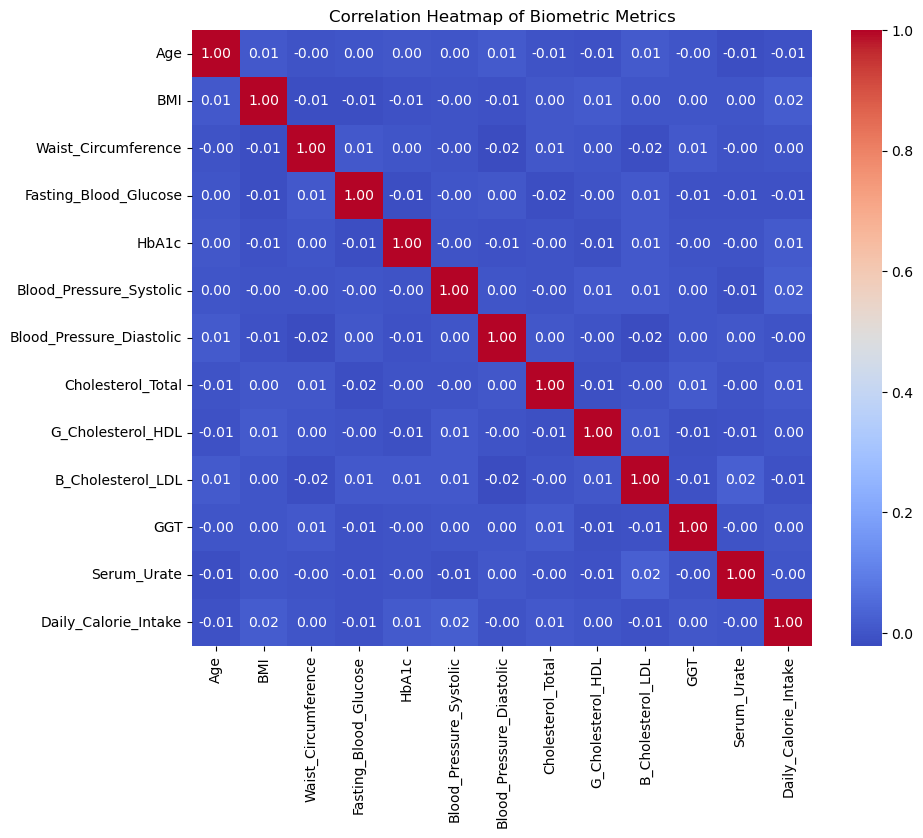

```python
# Required Visualization: Create a heatmap to understand the correlation analysis
correlation_matrix = df_cleaned[numeric_cols].corr()

# Correlation Heatmap using only numeric columns
plt.figure(figsize=(10, 8))
correlation_matrix = df_cleaned[numeric_cols].corr()
sns.heatmap(correlation_matrix, annot=True, cmap='coolwarm', fmt='.2f', cbar=True)
plt.title('Correlation Heatmap of Biometric Metrics')

# Save plot
plt.savefig(os.path.join('C:/Users/pfmij/In_Class_Assignments/Monique_Bucknor_Proj2FinalProj/Monique_Bucknor_Final_Proj', 'Required Visualization Correlation Heatmap of Biometric Metrics.png'))

# Show plot
plt.show()
```

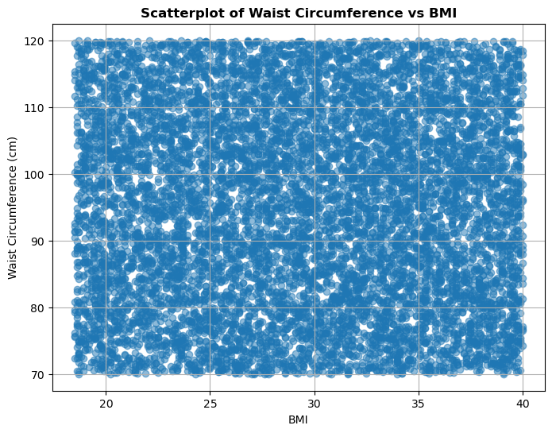

```python
# Required Visualization: Scatterplot of BMI vs Waist Circumference
plt.figure(figsize=(8, 6))
plt.scatter(df_cleaned['BMI'], df_cleaned['Waist_Circumference'], alpha=0.5)
plt.title('Scatterplot of Waist Circumference vs BMI', fontweight='bold')
plt.xlabel('BMI')
plt.ylabel('Waist Circumference (cm)')
plt.grid(True)

# Save plot
plt.savefig(os.path.join('C:/Users/pfmij/In_Class_Assignments/Monique_Bucknor_Proj2FinalProj/Monique_Bucknor_Final_Proj', 'Required Visualization Scatterplot of Waist Circumference vs BMI.png'))

# Show plot
plt.show()
```

**Interpretation**: Scatterplot shows no correlation. Decided to investigate via Metabolic Syndrome Score.

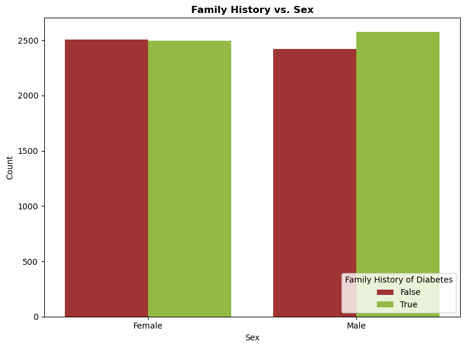

```python
# Required Visualization: Create countplot using seaborn of Family History vs. Sex
plt.figure(figsize=(8, 6))

# Create countplot of Family History vs. Sex with custom colors
plt.figure(figsize=(8, 6))
sns.countplot(data=df_cleaned, x='Sex', hue='Family_History_of_Diabetes', palette={False: 'firebrick', True: 'yellowgreen'})

# Set title and X label
plt.title('Family History vs. Sex', fontweight='bold')
plt.xlabel('Sex')
plt.ylabel('Count')

# Adjust and display layout
plt.tight_layout()
plt.legend(title='Family History of Diabetes', loc='lower right') # Adjust location of legend

# Save plot
plt.savefig(os.path.join('C:/Users/pfmij/In_Class_Assignments/Monique_Bucknor_Proj2FinalProj/Monique_Bucknor_Final_Proj', 'Required Visualization of Family History vs. Sex.png'))

# Show plot
plt.show()
```

**Interpretation**: For the countplot of family history via sex, there is a lack of relationship between male and female, as they have about the same number of people within each category. However, within the male category, there are more people with a family history of diabetes than those who do not.  
This can be interpreted as a slight but noteworthy trend where males are more likely to report a family history of diabetes compared to females, though the overall difference between the sexes is not substantial enough to make strong conclusions.

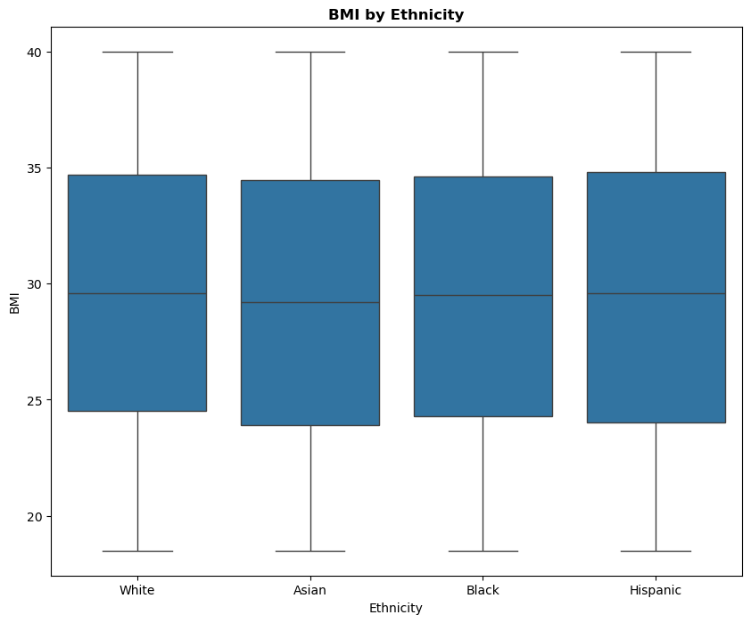

```python
# Required Visualization: Create boxplot using seaborn/matplotlib of BMI by Ethnicity
plt.figure(figsize=(10, 8))
sns.boxplot(data=df_cleaned, x='Ethnicity', y='BMI' )
plt.title('BMI by Ethnicity', fontweight='bold')
plt.xlabel('Ethnicity')
plt.ylabel('BMI')

# Save plot
plt.savefig(os.path.join('C:/Users/pfmij/In_Class_Assignments/Monique_Bucknor_Proj2FinalProj/Monique_Bucknor_Final_Proj', 'Required Visualization BMI by Ethnicity.png'))

# Show plot
plt.show()
```

**Interpretation**: Within the BMI vs. Ethnicity boxplot, there is very little difference between each ethnicity. Only a slight shift towards a higher BMI within the white population is observed, but it is not notable enough to draw significant conclusions. A separate boxplot was created to look further into this relationship via sex, in order to explore whether there are any gender-specific trends that might be influencing the overall pattern.

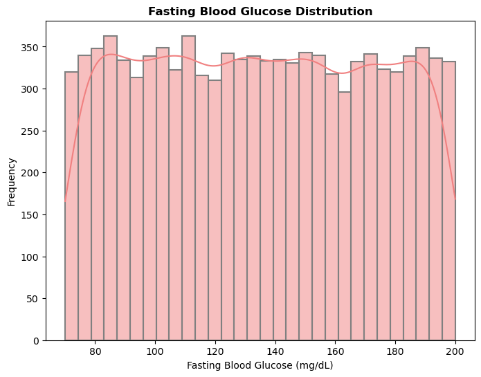

```python
# Required Visualization: Create histogram using seaborn/matplotlib of Fasting Blood Glucose
plt.figure(figsize=(8, 6))
sns.histplot(df_cleaned['Fasting_Blood_Glucose'], kde=True, color='lightcoral', edgecolor='gray', linewidth=1.5, bins=30)
plt.title('Fasting Blood Glucose Distribution', fontweight='bold')
plt.xlabel('Fasting Blood Glucose (mg/dL)')
plt.ylabel('Frequency')

# Save plot
plt.savefig(os.path.join('C:/Users/pfmij/In_Class_Assignments/Monique_Bucknor_Proj2FinalProj/Monique_Bucknor_Final_Proj', 'Required Visualization Fasting Blood Glucose Distribution.png'))

# Show plot
plt.show()
```

**Interpretation**: For the Fasting Blood Glucose distribution, not much can be drawn from it. There is a slight peak in frequency from 80 to 120, however, it varies just as much throughout the rest of the distribution. One can interpret that fasting blood glucose levels in this dataset show a broad range of values with no clear, consistent concentration around any particular level, this suggesting significant variability in glucose levels across the sample. This could indicate diverse health conditions within the population.

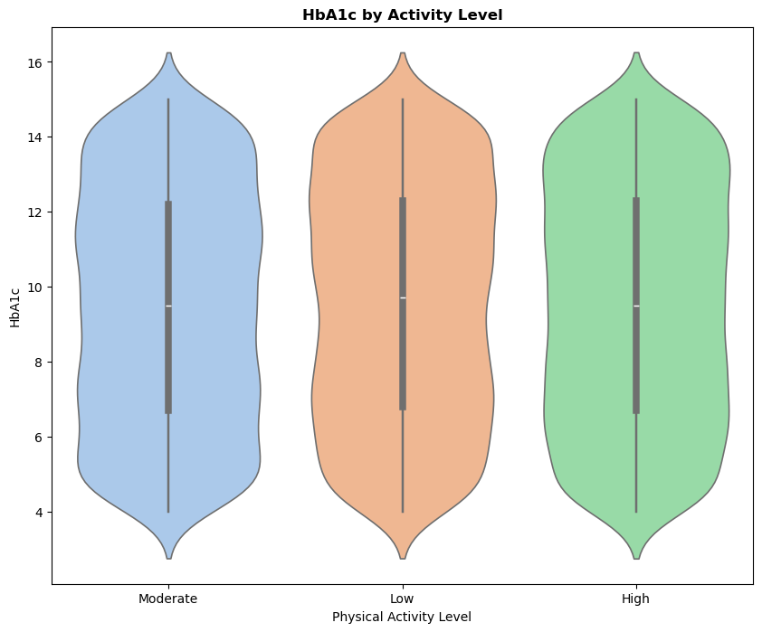

```python
# Required Visualization: Create violin plot using seaborn/matplotlib of HbA1c by Activity Level
plt.figure(figsize=(10, 8))
sns.violinplot(data=df_cleaned, x='Physical_Activity_Level', y='HbA1c', palette='pastel', hue='Physical_Activity_Level',
    linewidth=1.2)
plt.title('HbA1c by Activity Level', fontweight = 'bold')
plt.xlabel('Physical Activity Level')
plt.ylabel('HbA1c')

# Save plot
plt.savefig(os.path.join('C:/Users/pfmij/In_Class_Assignments/Monique_Bucknor_Proj2FinalProj/Monique_Bucknor_Final_Proj', 'Required Visualization HbA1c by Activity Level.png'))

# Show plot
plt.show()
```

**Interpretation**: For the HbA1c by Activity Level violin plot, one can see that the plots are relatively equal, with similar distributions across all activity levels. However, the moderate physical activity level displays visible bumps in the violin's shape. One can interpret that moderate physical activity may be associated with more variation in HbA1c levels compared to low or high activity levels, suggesting that individuals engaging in moderate physical activity may experience a wider range of HbA1c values, potentially indicating differences in how activity influences blood sugar control at this level.

### ADDITIONAL ANALYSIS/FINDINGS

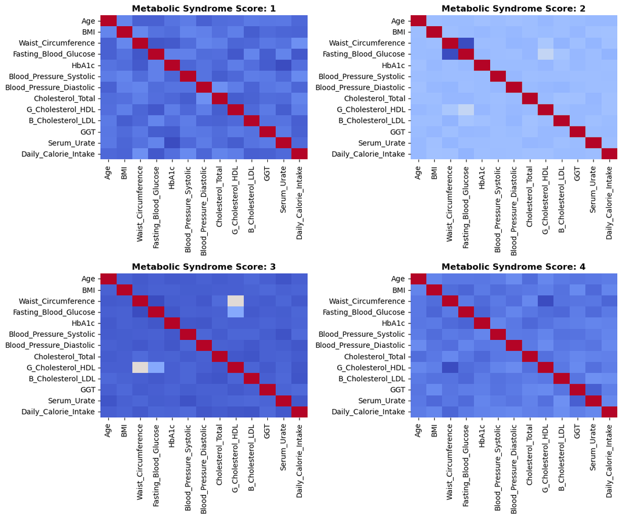

```python
# Set up the 2x2 subplot grid
fig, axes = plt.subplots(2, 2, figsize=(12, 10))

# There are no scores of 0.

# For Metabolic Syndrome Score 1
score_1_group = df_cleaned[df_cleaned['Metabolic_Syndrome_Score'] == 1]
corr_1 = score_1_group[numeric_cols].corr()
sns.heatmap(corr_1, annot=False, cmap='coolwarm', fmt='.2f', cbar=False, ax=axes[0, 0])
axes[0, 0].set_title('Metabolic Syndrome Score: 1', fontweight='bold')

# For Metabolic Syndrome Score 2
score_2_group = df_cleaned[df_cleaned['Metabolic_Syndrome_Score'] == 2]
corr_2 = score_2_group[numeric_cols].corr()
sns.heatmap(corr_2, annot=False, cmap='coolwarm', fmt='.2f', cbar=False, ax=axes[0, 1])
axes[0, 1].set_title('Metabolic Syndrome Score: 2', fontweight='bold')

# For Metabolic Syndrome Score 3
score_3_group = df_cleaned[df_cleaned['Metabolic_Syndrome_Score'] == 3]
corr_3 = score_3_group[numeric_cols].corr()
sns.heatmap(corr_3, annot=False, cmap='coolwarm', fmt='.2f', cbar=False, ax=axes[1, 0])
axes[1, 0].set_title('Metabolic Syndrome Score: 3', fontweight='bold')

# For Metabolic Syndrome Score 4
score_4_group = df_cleaned[df_cleaned['Metabolic_Syndrome_Score'] == 4]
corr_4 = score_4_group[numeric_cols].corr()
sns.heatmap(corr_4, annot=False, cmap='coolwarm', fmt='.2f', cbar=False, ax=axes[1, 1])
axes[1, 1].set_title('Metabolic Syndrome Score: 4', fontweight='bold')


# Adjust layout
plt.tight_layout()

# Save plot
plt.savefig(os.path.join('C:/Users/pfmij/In_Class_Assignments/Monique_Bucknor_Proj2FinalProj/Monique_Bucknor_Final_Proj', 'Subplots of Metabolic Syndrome Scores Heatmaps'))

# Show plot
plt.show()
```

**Interpretation**: Provided definition through Metabolic Syndrome score. Each scores has a different heat map, especially metabolic syndrome score 3 and 2. As seen there has been a shift in correlation in all cases. Specificity will be provided in next interpretations.

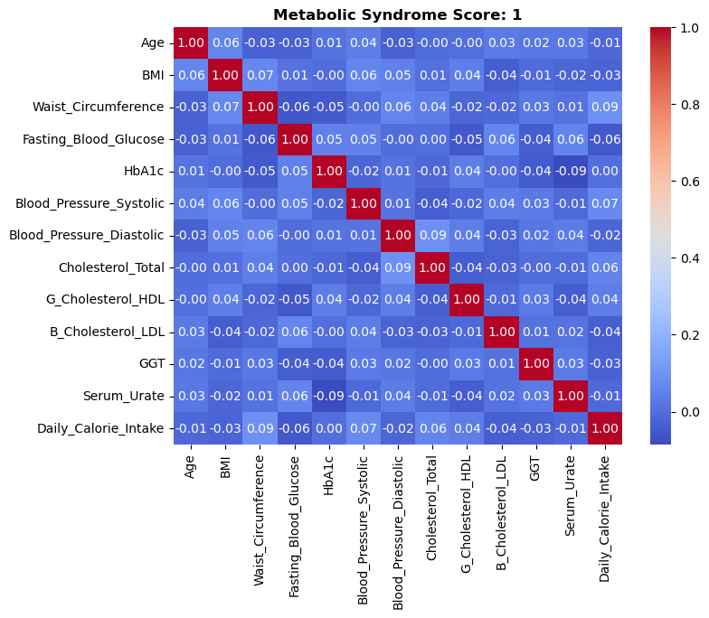

```python
# For Metabolic Syndrome Score 1
plt.figure(figsize=(8, 6))
score_1_group = df_cleaned[df_cleaned['Metabolic_Syndrome_Score'] == 1]
corr_1 = score_1_group[numeric_cols].corr()
sns.heatmap(corr_1, annot=True, cmap='coolwarm', fmt='.2f', cbar=True)
plt.title('Metabolic Syndrome Score: 1', fontweight='bold')

# Save plot
plt.savefig(os.path.join('C:/Users/pfmij/In_Class_Assignments/Monique_Bucknor_Proj2FinalProj/Monique_Bucknor_Final_Proj', 'Metabolic Syndrome Score 1 Heatmap.png'))

# Show plot
plt.show()
```

**Interpretation**: Metabolic syndrome score 1's heatmap provides similarly little correlations; however, closer to meaningful negative correlations exist within HbA1c and Serum_Urate, indicating that as HbA1c levels increase, Serum Urate levels tend to decrease. This suggests a potential inverse relationship between these two variables. Additionally, in Waist Circumference and Blood Pressure Diastolic (0.06) and Fasting Blood Glucose (-0.06), indicating that although these correlations are weak, there may be slight negative associations between Waist Circumference and Fasting Blood Glucose, as well as a possible slight positive relationship between Waist Circumference and Blood Pressure Diastolic.

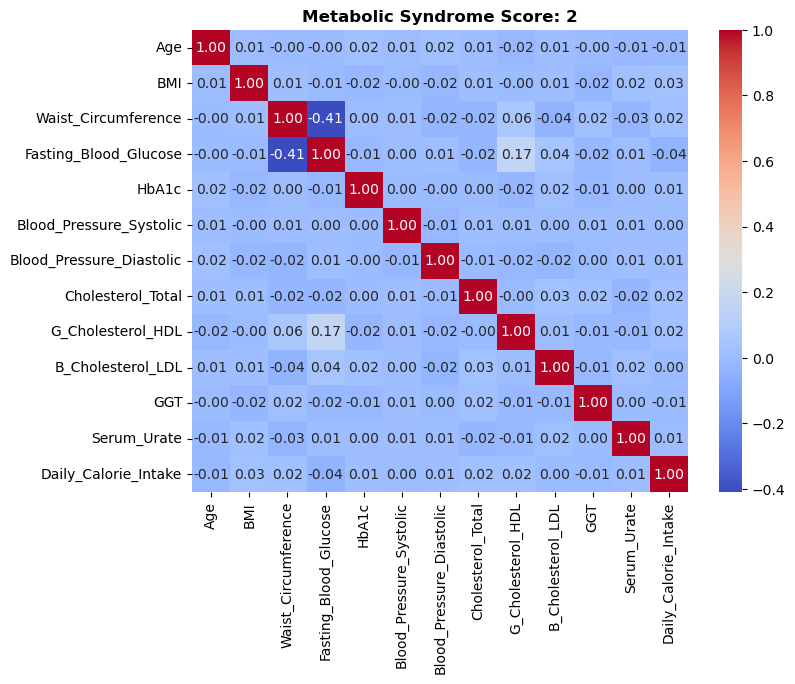

```python
# For Metabolic Syndrome Score 2
plt.figure(figsize=(8, 6))
score_2_group = df_cleaned[df_cleaned['Metabolic_Syndrome_Score'] == 2]
corr_2 = score_2_group[numeric_cols].corr()
sns.heatmap(corr_2, annot=True, cmap='coolwarm', fmt='.2f', cbar=True)
plt.title('Metabolic Syndrome Score: 2', fontweight='bold')

# Save plot
plt.savefig(os.path.join('C:/Users/pfmij/In_Class_Assignments/Monique_Bucknor_Proj2FinalProj/Monique_Bucknor_Final_Proj', 'Metabolic Syndrome Score 2 Heatmap.png'))

# Show plot
plt.show()
```

**Interpretation**: Metabolic Syndrome Score 2's heatmap indicates relatively no correlation throughout all variables. However, there is a positive correlation (0.17) between fasting blood glucose and Cholesterol HDL, indicating that as fasting blood glucose levels increase, cholesterol HDL levels tend to increase slightly as well, though the relationship is weak. There is a negative medium correlation between waist circumference and fasting blood glucose (-0.41), indicating that as waist circumference increases, fasting blood glucose tends to decrease moderately, suggesting that individuals with larger waist measurements might experience lower fasting glucose levels, which could be linked to other underlying factors or measurement differences.

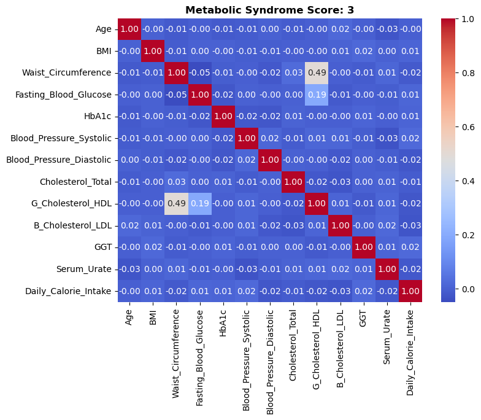

```python
# For Metabolic Syndrome Score 3
plt.figure(figsize=(8, 6))
score_3_group = df_cleaned[df_cleaned['Metabolic_Syndrome_Score'] == 3]
corr_3 = score_3_group[numeric_cols].corr()
sns.heatmap(corr_3, annot=True, cmap='coolwarm', fmt='.2f', cbar=True)
plt.title('Metabolic Syndrome Score: 3', fontweight='bold')

# Save plot
plt.savefig(os.path.join('C:/Users/pfmij/In_Class_Assignments/Monique_Bucknor_Proj2FinalProj/Monique_Bucknor_Final_Proj', 'Metabolic Syndrome Score 3 Heatmap.png'))

# Show plot
plt.show()
```

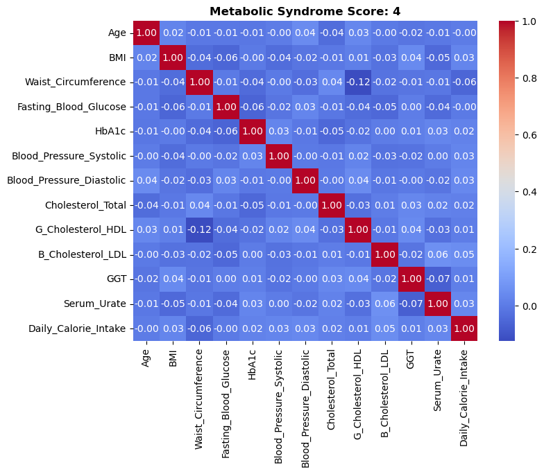

```python
# For Metabolic Syndrome Score 4
plt.figure(figsize=(8, 6))
score_4_group = df_cleaned[df_cleaned['Metabolic_Syndrome_Score'] == 4]
corr_4 = score_4_group[numeric_cols].corr()
sns.heatmap(corr_4, annot=True, cmap='coolwarm', fmt='.2f', cbar=True)
plt.title('Metabolic Syndrome Score: 4', fontweight='bold')

# Save plot
plt.savefig(os.path.join('C:/Users/pfmij/In_Class_Assignments/Monique_Bucknor_Proj2FinalProj/Monique_Bucknor_Final_Proj', 'Metabolic Syndrome Score 4 Heatmap.png'))

# Show plot
plt.show()
```

**Interpretation**: For Metabolic Syndrome Score 4's heatmap, there is relatively no notable correlation between most of the biometrics. However, between waist circumference and cholesterol HDL, one can note that there is a low negative correlation (-0.12), meaning that as waist circumference increases, cholesterol HDL levels tend to decrease slightly, although the relationship is weak and not strong enough to suggest a significant impact.

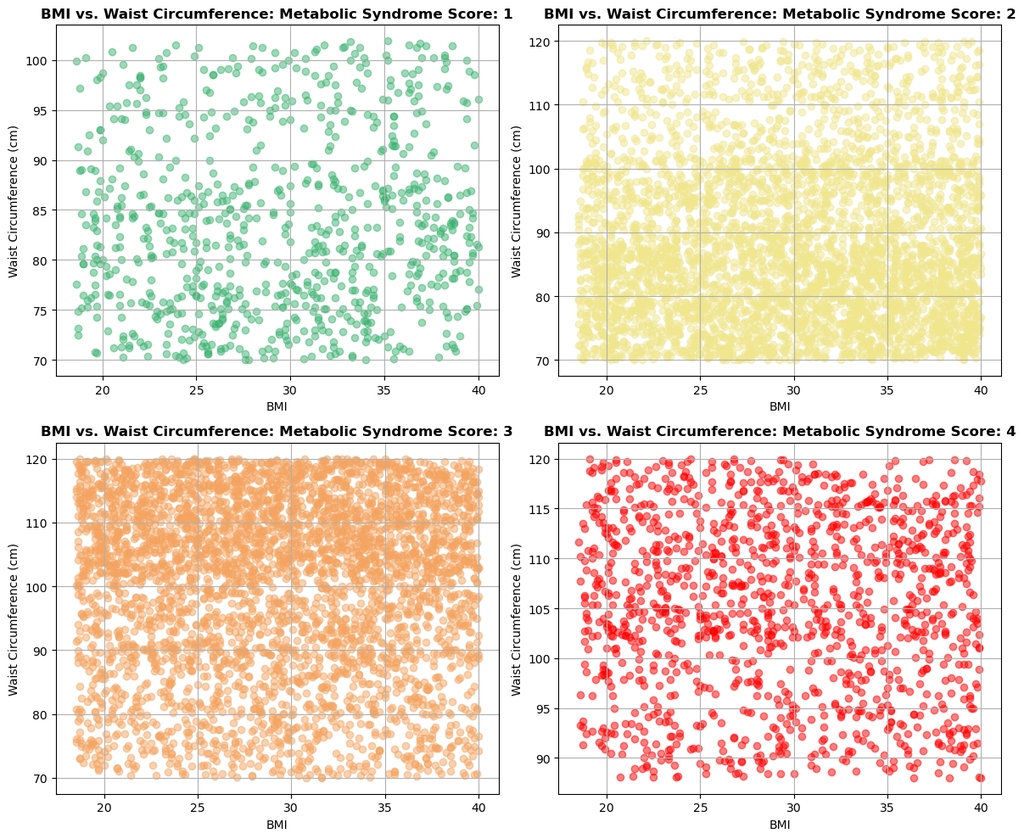

```python
# Set up the 2x2 subplot grid
fig, axes = plt.subplots(2, 2, figsize=(12, 10))

# There are no scores of 0.

# For Metabolic Syndrome Score 1
axes[0, 0].scatter(score_1_group['BMI'], score_1_group['Waist_Circumference'], alpha=0.5, color='mediumseagreen')
axes[0, 0].set_title('BMI vs. Waist Circumference: Metabolic Syndrome Score: 1', fontweight='bold')
axes[0, 0].set_xlabel('BMI')
axes[0, 0].set_ylabel('Waist Circumference (cm)')
axes[0, 0].grid(True)

# For Metabolic Syndrome Score 2
axes[0, 1].scatter(score_2_group['BMI'], score_2_group['Waist_Circumference'], alpha=0.5, color='khaki')
axes[0, 1].set_title('BMI vs. Waist Circumference: Metabolic Syndrome Score: 2', fontweight='bold')
axes[0, 1].set_xlabel('BMI')
axes[0, 1].set_ylabel('Waist Circumference (cm)')
axes[0, 1].grid(True)

# For Metabolic Syndrome Score 3
axes[1, 0].scatter(score_3_group['BMI'], score_3_group['Waist_Circumference'], alpha=0.5, color='sandybrown')
axes[1, 0].set_title('BMI vs. Waist Circumference: Metabolic Syndrome Score: 3', fontweight='bold')
axes[1, 0].set_xlabel('BMI')
axes[1, 0].set_ylabel('Waist Circumference (cm)')
axes[1, 0].grid(True)

# For Metabolic Syndrome Score 4
axes[1, 1].scatter(score_4_group['BMI'], score_4_group['Waist_Circumference'], alpha=0.5, color='red')
axes[1, 1].set_title('BMI vs. Waist Circumference: Metabolic Syndrome Score: 4', fontweight='bold')
axes[1, 1].set_xlabel('BMI')
axes[1, 1].set_ylabel('Waist Circumference (cm)')
axes[1, 1].grid(True)

# Adjust layout
plt.tight_layout()

# Save plot
plt.savefig(os.path.join('C:/Users/pfmij/In_Class_Assignments/Monique_Bucknor_Proj2FinalProj/Monique_Bucknor_Final_Proj', 'Subplots of BMI vs. Waist Circumference Metabolic Syndrome Scores.png'))

# Show plot
plt.show()
```

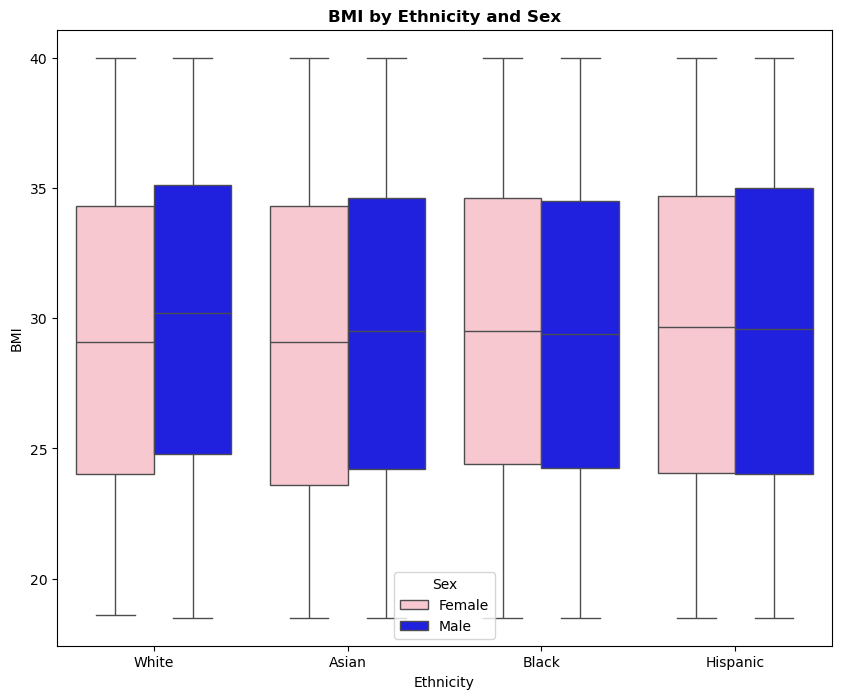

```python
# Create boxplot using seaborn/matplotlib of BMI by Ethnicity (Added Sex)
plt.figure(figsize=(10, 8))
sns.boxplot(data=df_cleaned, x='Ethnicity', y='BMI',
            palette={"Female": 'pink', "Male": 'blue'},
            hue='Sex') #Added Sex for deeper analysis
plt.title('BMI by Ethnicity and Sex', fontweight='bold')
plt.xlabel('Ethnicity')
plt.ylabel('BMI')

# Save plot
plt.savefig(os.path.join('C:/Users/pfmij/In_Class_Assignments/Monique_Bucknor_Proj2FinalProj/Monique_Bucknor_Final_Proj', 'BMI by Ethnicity and Sex.png'))

# Show plot
plt.show()
```

**Interpretation**: Within the BMI vs. Ethnicity via Sex boxplot, we can see that within the white category, there is a tendency for males to have a higher BMI than females. In the Asian category, the same applies, although the difference is smaller than in the white group. Black and Hispanic populations show equal BMI distributions between males and females. One can interpret that gender differences in BMI are more prominent in certain ethnicities, such as white and Asian populations, while the relationship between sex and BMI seems less significant in Black and Hispanic populations.  
Additionally, BMI *may not be an accurate measure* of health for people of color, as it does not account for differences in body composition, muscle mass, or fat distribution, which can vary significantly across ethnic groups.

Providing some interactive plots using Plotly.

```python
# Create histogram plot
histogramsmokingalcohol = px.histogram(df_cleaned,
                   x='Metabolic_Syndrome_Score',
                   color='Smoking_Status',
                   barmode='stack',
                   title='Smoking by Metabolic Syndrome Score',
                   labels={'Metabolic_Syndrome_Score': 'Metabolic Syndrome Score', 'Smoking_Status': 'Smoking Status'})

#Save histogram
histogramsmokingalcohol.write_html(os.path.join('C:/Users/pfmij/In_Class_Assignments/Monique_Bucknor_Proj2FinalProj/Monique_Bucknor_Final_Proj', 'Smoking by Metabolic Syndrome Score.html'))

#Show histogram
histogramsmokingalcohol.show()
```

[interactive chart not shown]

**Interpretation**: Within the Smoking by Metabolic Syndrome Score, one can note that most of the distribution falls within metabolic scores of 2 and 3. Most former smokers lie within this category as well. The ratio between current smokers, former smokers, and never smokers remains relatively equal. This shows that smoking itself has no clear relationship with metabolic syndrome score. One can interpret that while smoking status is distributed across various metabolic syndrome scores, it does not appear to have a strong correlation with the severity of metabolic syndrome, suggesting that other factors may be more influential in determining metabolic health.

```python
# Create heatmap of lifestyle score vs metabolic syndrome score
heatmap = px.density_heatmap(
    df_cleaned,
    x='Lifestyle_Score',
    y='Metabolic_Syndrome_Score',
    z=None,
    histfunc='count',
    color_continuous_scale='Viridis',
    title='Heatmap of Lifestyle Score vs Metabolic Syndrome Score',
)

# Set titles of x and y axis
heatmap.update_layout(
    xaxis_title='Lifestyle Score',
    yaxis_title='Metabolic Syndrome Score',
    coloraxis_colorbar=dict(title='Count'),
)

#Save histogram
heatmap.write_html(os.path.join('C:/Users/pfmij/In_Class_Assignments/Monique_Bucknor_Proj2FinalProj/Monique_Bucknor_Final_Proj', 'Heatmap of Lifestyle Score vs Metabolic Syndrome Score.html'))

# Show map
heatmap.show()
```

[interactive chart not shown]

**Interpretation**: The heatmap of lifestyle score and metabolic syndrome score reveals a strong concentration of individuals with metabolic syndrome scores of 2 and 3, which are typically associated with the highest frequency of lifestyle scores of 1. This suggests that individuals with mid-range metabolic syndrome scores are more likely to have lower lifestyle scores, indicating that a poorer lifestyle may be more common among those with moderate metabolic syndrome risk. Interestingly, as the metabolic syndrome score increases, there is a noticeable trend towards higher lifestyle scores as well. This could imply that individuals with more severe metabolic syndrome (higher scores) might adopt slightly healthier lifestyles, though the exact relationship remains more complex. This insight may point to lifestyle factors influencing metabolic syndrome risk, but further investigation would be needed to draw definitive conclusions.

### INSIGHTS AND GENERALIZATIONS

To conclude, while no *single variable* perfectly predicted diabetes risk in this dataset, the analysis reinforced an important theme: chronic conditions, in this case, diabetes, emerge from the complex interaction of hereditary, lifestyle, and biometric factors. Real-world data, even synthetic data, may rarely offer simple answers, so this exploration highlights the need for even deeper multifactoral approaches when studying disease risk.

### References:

American Heart Association (AHA) and National Heart, Lung, and Blood Institute (NHLBI). Diagnosis and Management of the Metabolic Syndrome: An American Heart Association/National Heart, Lung, and Blood Institute Scientific Statement. Circulation, 2005; 112(17): 2735–2752. https://www.ahajournals.org/doi/10.1161/CIRCULATIONAHA.105.169404

Centers for Disease Control and Prevention (CDC). Trends in Metabolic Syndrome Prevalence by Race/Ethnicity and Sex in the United States, 1988–2012. Preventing Chronic Disease, 2017; 14: E24. https://www.cdc.gov/pcd/issues/2017/16_0287.htm

Marshall Patel. (2025). Diabetes_prediction_dataset [Data set]. Kaggle. https://doi.org/10.34740/KAGGLE/DS/6934503

National Cholesterol Education Program (NCEP) Adult Treatment Panel III. Executive Summary of The Third Report of The National Cholesterol Education Program (NCEP) Expert Panel on Detection, Evaluation, And Treatment of High Blood Cholesterol In Adults (Adult Treatment Panel III). Journal of the American Medical Association (JAMA), 2001; 285(19): 2486–2497. https://jamanetwork.com/journals/jama/fullarticle/193847